# Clase 4 - Boosting

```r
# Instalar engine xgboost
#install.packages("xgboost")
```

# Cierre de ensambles

Vamos a terminar de ver ensambles con modelos de boosting. Como vimos en la parte teórica, estos modelos tienen la característica de realizar un aprendizaje iterativo sobre estimadores que se construyen secuencialmente. Vamos a trabajar sobre la base de la ENUT para predecir si se realiza TD o no, y comparar con los resultados de los modelos anteriores.

Primero, hacemos el preprocesamiento:

```r
library(tidyverse)

data <- read_delim("./data/enut2021_base.txt", delim = "|")
data <- data %>% select(ID, SEXO_SEL, EDAD_SEL, TCS_GRUPO_DOMESTICO, CONDICION_ACTIVIDAD_AGRUPADA,
                        NIVEL_EDUCATIVO_AGRUPADO, CANT_DEMANDANTES_TOTAL, CANT_NODEMANDANTES_TOTAL,
                        BHCH04_SEL, BHDC_SEL) %>%
  mutate(realiza_domest = as.factor(case_when(
    TCS_GRUPO_DOMESTICO > 60 ~ "Realiza",
    TRUE ~ "No realiza")))

data <- data %>% mutate_at(
                   vars(SEXO_SEL),
                    ~as.factor(case_when(
                      . == 1 ~ "Mujer",
                      . == 2 ~ "Varon"
                    )))


data <- data %>% mutate_at(vars(CONDICION_ACTIVIDAD_AGRUPADA),
                   ~as.factor(case_when(
                     . == 1 ~ "Ocupado",
                     . == 2 ~ "No ocupado"
                   )))

data <- data %>% mutate_at(vars(BHCH04_SEL),
                   ~as.factor(case_when(
                     . == 1 ~ "Jefe/a",
                     . == 2 ~ "Conyuge/pareja",
                     . == 3 ~ "Hijo/a",
                     . == 4 ~ "Hijastro/a",
                     . == 5 ~ "Yerno/nuera",
                     . == 6 ~ "Nieto/a",
                     . == 7 ~ "Padre o madre",
                     . == 8 ~ "Suegro/a",
                     . == 9 ~ "Hermano/a",
                     . == 10 ~ "Cuniado/a",
                     . == 11 ~ "Sobrino/a",
                     . == 12 ~ "Abuelo/a",
                     . == 13 ~ "Otro familiar",
                     . == 14 ~ "Otro no familiar")))



 data <- data %>% mutate_at(vars(BHDC_SEL),
                   ~as.factor(case_when(
                     . == 0 ~ "No es demandante de cuidado",
                     . == 1 ~ "Es demandante de cuidado"
                   )))

data<- data %>% select(-TCS_GRUPO_DOMESTICO)
```

## Árboles simples y modelos de bagging

Recordemos los modelos previos.

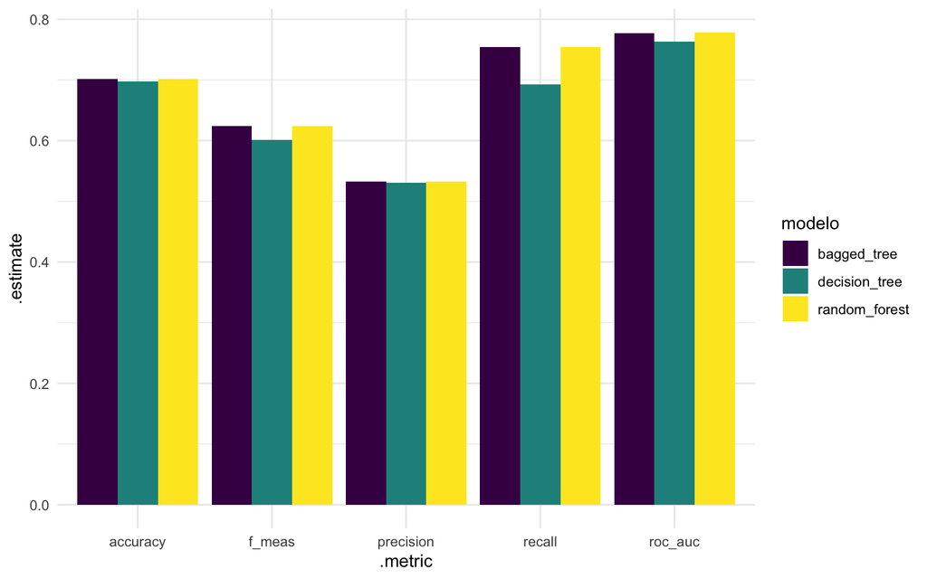

```r
decision_tree <- readRDS('./data/validation_test_dt.RDS')
bagging <- readRDS('./data/validation_test_bag.RDS')
random_forest <- readRDS('./data/validation_rf.RDS')

datasets <- list(decision_tree, bagging, random_forest)

class_metrics <- metric_set(precision, recall,
                       accuracy, f_meas)

metrics_dt <- roc_auc(decision_tree, truth = realiza_domest, ".pred_No realiza") %>%
  bind_rows(., class_metrics(decision_tree, truth = realiza_domest, estimate = .pred_class)) %>%
  mutate(modelo = "decision_tree")

metrics_bagging <- roc_auc(bagging, truth = realiza_domest, ".pred_No realiza") %>%
  bind_rows(., class_metrics(bagging, truth = realiza_domest, estimate = .pred_class))%>%
  mutate(modelo = "bagged_tree")

metrics_rf <- roc_auc(random_forest, truth = realiza_domest, ".pred_No realiza") %>%
  bind_rows(., class_metrics(bagging, truth = realiza_domest, estimate = .pred_class))%>%
  mutate(modelo = "random_forest")

rbind(metrics_dt, metrics_bagging, metrics_rf) %>%
ggplot(aes(x = .metric, y = .estimate, fill = modelo))+
  geom_col(position = "dodge")+
  scale_fill_viridis_d()+
  theme_minimal()
```

- ¿Qué modelo funciona mejor? ¿Por qué?

## Boosting

Vamos a realizar un modelo de boosting con `tidymodels`. Primero, importamos la librería:

```r
library(tidymodels)
```

Hacemos la partición de datos y preprocesamiento del workflow:

```r
set.seed(123)

split <- initial_split(data)
train <- training(split)
test <- testing(split)

recipe <- recipe(realiza_domest ~ ., data = train)%>%
  update_role(ID, new_role = "id") %>%
  step_other(BHCH04_SEL, threshold = 0.2)%>%
  # El engine XGBoost necesita que transformemos las variables categoricas a dummy
  step_dummy(SEXO_SEL) %>%
  step_dummy(CONDICION_ACTIVIDAD_AGRUPADA) %>%
  step_dummy(BHCH04_SEL) %>%
  step_dummy(BHDC_SEL) %>%
  step_downsample(realiza_domest, under_ratio = 1)

wf <- workflow() %>%
  add_recipe(recipe)
```

Ahora, viene la parte de especificar la información del modelo. Como estamos trabajando con boosting, empezamos pasando el parámetro `boost_tree()`. Para elegir entre los tipos de modelos de boosting posibles, hay que modificar el parámetro de `set_engine()`. Por default, tidymodels usa el parámetro `xgboost`para modelos de boosting. Existen otros engines, como el C5.0 que sigue un procedimiento similar a AdaBoosting, un ensamble de árboles que hacen un voto ponderado para asignar a la clase final.

```r
bt_spec <- boost_tree(
  # Estos son los hiperparámetros mas utilizados en ensamble,
  # learn_rate es propio gradiant boosting
  trees = tune(),
  mtry = tune(),
  tree_depth = tune(),
  learn_rate = tune()) %>%
  # Usamos el engine xgboost para poder utilizar el hiperparámetro learn_rate
  set_engine("xgboost") %>%
  set_mode("classification")

bt_spec %>% translate()
```

```
## Boosted Tree Model Specification (classification)
##
## Main Arguments:
##   mtry = tune()
##   trees = tune()
##   tree_depth = tune()
##   learn_rate = tune()
##
## Computational engine: xgboost
##
## Model fit template:
## parsnip::xgb_train(x = missing_arg(), y = missing_arg(), weights = missing_arg(),
##     colsample_bynode = tune(), nrounds = tune(), max_depth = tune(),
##     eta = tune(), nthread = 1, verbose = 0)
```

```r
doParallel::registerDoParallel()

tune_wf <- wf %>%
  add_model(bt_spec)

set.seed(912)

folds <- vfold_cv(train)

tune_params <- tune_wf %>%
   tune_grid(folds,
             metrics = metric_set(precision, recall,
                               roc_auc, f_meas),
             grid = 20)
```

```
## i Creating pre-processing data to finalize unknown parameter: mtry
```

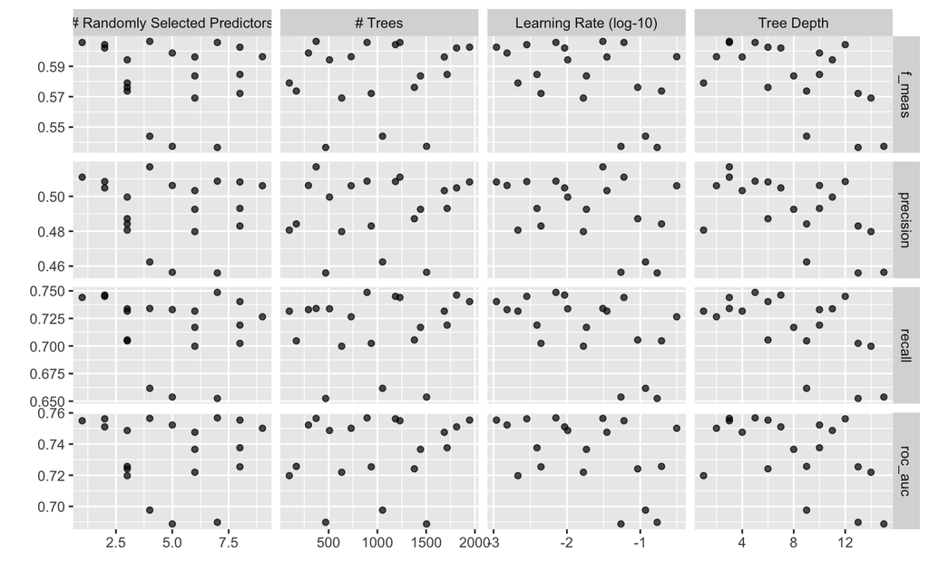

```r
autoplot(tune_params)
```

```r
tune_params %>%
  collect_metrics()
```

```
## # A tibble: 80 × 10
##     mtry trees tree_depth learn_rate .metric   .estimator  mean     n std_err
##    <int> <int>      <int>      <dbl> <chr>     <chr>      <dbl> <int>   <dbl>
##  1     1  1231          3    0.0599  f_meas    binary     0.606    10 0.00486
##  2     1  1231          3    0.0599  precision binary     0.511    10 0.00576
##  3     1  1231          3    0.0599  recall    binary     0.744    10 0.00655
##  4     1  1231          3    0.0599  roc_auc   binary     0.755    10 0.00741
##  5     2  1812          7    0.00930 f_meas    binary     0.602    10 0.00682
##  6     2  1812          7    0.00930 precision binary     0.505    10 0.00723
##  7     2  1812          7    0.00930 recall    binary     0.746    10 0.00794
##  8     2  1812          7    0.00930 roc_auc   binary     0.751    10 0.00636
##  9     2  1185         12    0.00284 f_meas    binary     0.604    10 0.00684
## 10     2  1185         12    0.00284 precision binary     0.508    10 0.00653
## # ℹ 70 more rows
## # ℹ 1 more variable: .config <chr>
```

```r
best_model <- select_best(tune_params, metric = "roc_auc")

final_model <- finalize_model(bt_spec, best_model)
```

```r
final_model
```

```
## Boosted Tree Model Specification (classification)
##
## Main Arguments:
##   mtry = 7
##   trees = 894
##   tree_depth = 5
##   learn_rate = 0.00707733316334377
##
## Computational engine: xgboost
```

Para finalizar, actualizamos el modelo tuneado en el workflow y lo fiteamos.

```r
tree_boost <- wf %>%
   update_model(final_model)
fit_tree <- tree_boost %>% fit(train)
```

Ahora, vamos a predecir sobre el test set, obtener las métricas de evaluación y compararlas con los otros modelos.

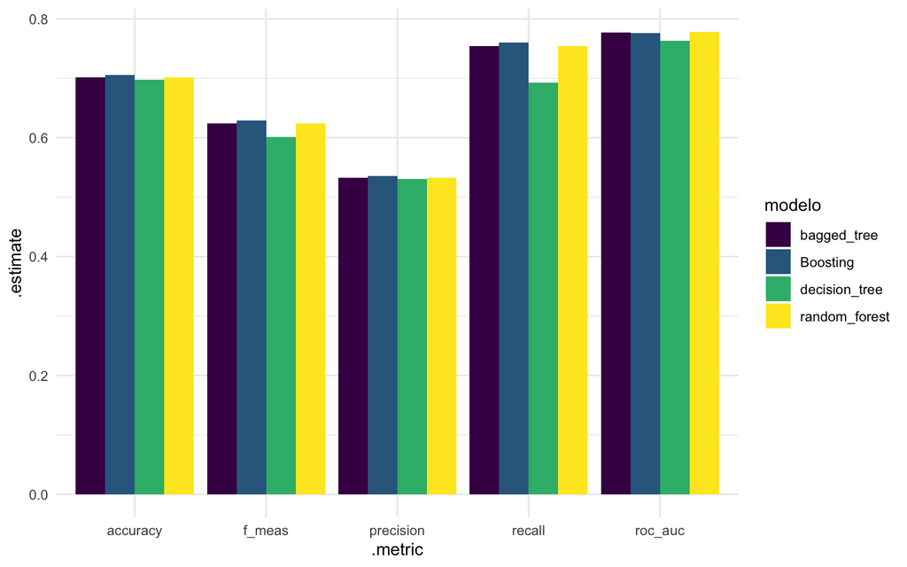

```r
boost_valid <- fit_tree %>%
  predict(test) %>%
  bind_cols(., test)

boost_valid <- predict(fit_tree, test, type = "prob") %>%
  bind_cols(boost_valid, .)


class_metrics <- metric_set(precision, recall,
                       accuracy, f_meas)

boost_metrics <- roc_auc(boost_valid, truth = realiza_domest, ".pred_No realiza") %>%
  bind_rows(class_metrics(boost_valid, truth = realiza_domest, estimate = .pred_class)) %>%
  mutate(modelo = "Boosting")

rbind(metrics_dt, metrics_bagging, metrics_rf, boost_metrics) %>%
ggplot(aes(x = .metric, y = .estimate, fill = modelo))+
  geom_col(position = "dodge")+
  scale_fill_viridis_d()+
  theme_minimal()
```

```r
boost_metrics
```

```
## # A tibble: 5 × 4
##   .metric   .estimator .estimate modelo
##   <chr>     <chr>          <dbl> <chr>
## 1 roc_auc   binary         0.776 Boosting
## 2 precision binary         0.536 Boosting
## 3 recall    binary         0.760 Boosting
## 4 accuracy  binary         0.705 Boosting
## 5 f_meas    binary         0.629 Boosting
```

Teniendo en cuenta qué significa cada métrica de evaluación, ¿qué pueden decir de los 4 modelos que probaron?

- ¿Cuál captura mayor cantidad de casos positivos?
- ¿Cuál captura con mayor exactitud los casos positivos?
- ¿Cuál funciona mejor en base a esos dos criterios? ¿Y peor?

```r
# Para feature imporance usando el engine xgboost tengo que importar la libreria
# y luego acceder al modelo entrenado con $fit$fit$fit, esto es muy propio de xgboost
library(xgboost)
xgb.importance(model=fit_tree$fit$fit$fit)
```

```
##                                 Feature       Gain      Cover  Frequency
## 1:                       SEXO_SEL_Varon 0.31243984 0.12675076 0.04701108
## 2:                             EDAD_SEL 0.22100198 0.39113056 0.37742478
## 3:                     BHCH04_SEL_other 0.13995437 0.05718410 0.02459422
## 4: CONDICION_ACTIVIDAD_AGRUPADA_Ocupado 0.11113207 0.10048434 0.07996833
## 5: BHDC_SEL_No.es.demandante.de.cuidado 0.07250318 0.05571281 0.05898654
## 6:             CANT_NODEMANDANTES_TOTAL 0.05500383 0.10052060 0.16666667
## 7:               CANT_DEMANDANTES_TOTAL 0.04423171 0.10095471 0.11525139
## 8:             NIVEL_EDUCATIVO_AGRUPADO 0.02538856 0.04175527 0.08709422
## 9:                    BHCH04_SEL_Jefe.a 0.01834447 0.02550684 0.04300277
```